# Risk Factor Analysis

## Outcome Variable

**Outcome Variable:** wasted

## Predictor Variables

**Intervention Variable:** hhwealth_quart

**Adjustment Set:**

- arm
- sex
- W_mage
- meducyrs
- feducyrs
- W_gagebrth
- W_birthwt
- W_birthlen
- W_nchldlt5
- W_parity
- delta_W_mage
- delta_meducyrs
- delta_feducyrs
- delta_W_gagebrth
- delta_W_birthwt
- delta_W_birthlen
- delta_W_nchldlt5
- delta_W_parity

## Stratifying Variables

The analysis was stratified on these variable(s):

- agecat
- studyid
- country

## Data Summary

| agecat | studyid | country | hhwealth_quart | wasted | n_cell | n |
| --- | --- | --- | --- | --- | --- | --- |
| Birth | ki0047075b-MAL-ED | BANGLADESH | Wealth Q4 | 0 | 19 | 76 |
| Birth | ki0047075b-MAL-ED | BANGLADESH | Wealth Q4 | 1 | 2 | 76 |
| Birth | ki0047075b-MAL-ED | BANGLADESH | Wealth Q1 | 0 | 12 | 76 |
| Birth | ki0047075b-MAL-ED | BANGLADESH | Wealth Q1 | 1 | 5 | 76 |
| Birth | ki0047075b-MAL-ED | BANGLADESH | Wealth Q2 | 0 | 14 | 76 |
| Birth | ki0047075b-MAL-ED | BANGLADESH | Wealth Q2 | 1 | 4 | 76 |
| Birth | ki0047075b-MAL-ED | BANGLADESH | Wealth Q3 | 0 | 19 | 76 |
| Birth | ki0047075b-MAL-ED | BANGLADESH | Wealth Q3 | 1 | 1 | 76 |
| Birth | ki0047075b-MAL-ED | INDIA | Wealth Q4 | 0 | 8 | 54 |
| Birth | ki0047075b-MAL-ED | INDIA | Wealth Q4 | 1 | 3 | 54 |
| Birth | ki0047075b-MAL-ED | INDIA | Wealth Q1 | 0 | 11 | 54 |
| Birth | ki0047075b-MAL-ED | INDIA | Wealth Q1 | 1 | 6 | 54 |
| Birth | ki0047075b-MAL-ED | INDIA | Wealth Q2 | 0 | 12 | 54 |
| Birth | ki0047075b-MAL-ED | INDIA | Wealth Q2 | 1 | 3 | 54 |
| Birth | ki0047075b-MAL-ED | INDIA | Wealth Q3 | 0 | 9 | 54 |
| Birth | ki0047075b-MAL-ED | INDIA | Wealth Q3 | 1 | 2 | 54 |
| Birth | ki0047075b-MAL-ED | NEPAL | Wealth Q4 | 0 | 9 | 30 |
| Birth | ki0047075b-MAL-ED | NEPAL | Wealth Q4 | 1 | 0 | 30 |
| Birth | ki0047075b-MAL-ED | NEPAL | Wealth Q1 | 0 | 7 | 30 |
| Birth | ki0047075b-MAL-ED | NEPAL | Wealth Q1 | 1 | 1 | 30 |
| Birth | ki0047075b-MAL-ED | NEPAL | Wealth Q2 | 0 | 5 | 30 |
| Birth | ki0047075b-MAL-ED | NEPAL | Wealth Q2 | 1 | 1 | 30 |
| Birth | ki0047075b-MAL-ED | NEPAL | Wealth Q3 | 0 | 5 | 30 |
| Birth | ki0047075b-MAL-ED | NEPAL | Wealth Q3 | 1 | 2 | 30 |
| Birth | ki0047075b-MAL-ED | PERU | Wealth Q4 | 0 | 10 | 36 |
| Birth | ki0047075b-MAL-ED | PERU | Wealth Q4 | 1 | 0 | 36 |
| Birth | ki0047075b-MAL-ED | PERU | Wealth Q1 | 0 | 8 | 36 |
| Birth | ki0047075b-MAL-ED | PERU | Wealth Q1 | 1 | 1 | 36 |
| Birth | ki0047075b-MAL-ED | PERU | Wealth Q2 | 0 | 9 | 36 |
| Birth | ki0047075b-MAL-ED | PERU | Wealth Q2 | 1 | 0 | 36 |

[output cut: 346 more lines]

The following strata were considered:

- agecat: 24 months, studyid: ki0047075b-MAL-ED, country: BANGLADESH
- agecat: 24 months, studyid: ki0047075b-MAL-ED, country: INDIA
- agecat: 24 months, studyid: ki0047075b-MAL-ED, country: NEPAL
- agecat: 24 months, studyid: ki0047075b-MAL-ED, country: PERU
- agecat: 24 months, studyid: ki0047075b-MAL-ED, country: SOUTH AFRICA
- agecat: 24 months, studyid: ki0047075b-MAL-ED, country: TANZANIA, UNITED REPUBLIC OF
- agecat: 24 months, studyid: ki1000108-CMC-V-BCS-2002, country: INDIA
- agecat: 24 months, studyid: ki1000108-IRC, country: INDIA
- agecat: 24 months, studyid: ki1017093b-PROVIDE, country: BANGLADESH
- agecat: 24 months, studyid: ki1066203-TanzaniaChild2, country: TANZANIA, UNITED REPUBLIC OF
- agecat: 24 months, studyid: ki1113344-GMS-Nepal, country: NEPAL
- agecat: 24 months, studyid: ki1114097-CONTENT, country: PERU
- agecat: 24 months, studyid: ki1135781-COHORTS, country: GUATEMALA
- agecat: 24 months, studyid: ki1135781-COHORTS, country: PHILIPPINES
- agecat: 24 months, studyid: ki1148112-LCNI-5, country: MALAWI
- agecat: 24 months, studyid: kiGH5241-JiVitA-3, country: BANGLADESH
- agecat: 24 months, studyid: kiGH5241-JiVitA-4, country: BANGLADESH
- agecat: 6 months, studyid: ki0047075b-MAL-ED, country: BANGLADESH
- agecat: 6 months, studyid: ki0047075b-MAL-ED, country: INDIA
- agecat: 6 months, studyid: ki0047075b-MAL-ED, country: NEPAL
- agecat: 6 months, studyid: ki0047075b-MAL-ED, country: PERU
- agecat: 6 months, studyid: ki0047075b-MAL-ED, country: SOUTH AFRICA
- agecat: 6 months, studyid: ki0047075b-MAL-ED, country: TANZANIA, UNITED REPUBLIC OF
- agecat: 6 months, studyid: ki1000108-CMC-V-BCS-2002, country: INDIA
- agecat: 6 months, studyid: ki1000108-IRC, country: INDIA
- agecat: 6 months, studyid: ki1017093b-PROVIDE, country: BANGLADESH
- agecat: 6 months, studyid: ki1066203-TanzaniaChild2, country: TANZANIA, UNITED REPUBLIC OF
- agecat: 6 months, studyid: ki1113344-GMS-Nepal, country: NEPAL
- agecat: 6 months, studyid: ki1114097-CONTENT, country: PERU
- agecat: 6 months, studyid: ki1135781-COHORTS, country: GUATEMALA
- agecat: 6 months, studyid: ki1135781-COHORTS, country: PHILIPPINES
- agecat: 6 months, studyid: ki1148112-LCNI-5, country: MALAWI
- agecat: 6 months, studyid: kiGH5241-JiVitA-3, country: BANGLADESH
- agecat: 6 months, studyid: kiGH5241-JiVitA-4, country: BANGLADESH
- agecat: Birth, studyid: ki0047075b-MAL-ED, country: BANGLADESH
- agecat: Birth, studyid: ki0047075b-MAL-ED, country: INDIA
- agecat: Birth, studyid: ki0047075b-MAL-ED, country: NEPAL
- agecat: Birth, studyid: ki0047075b-MAL-ED, country: PERU
- agecat: Birth, studyid: ki0047075b-MAL-ED, country: SOUTH AFRICA
- agecat: Birth, studyid: ki0047075b-MAL-ED, country: TANZANIA, UNITED REPUBLIC OF
- agecat: Birth, studyid: ki1000108-CMC-V-BCS-2002, country: INDIA
- agecat: Birth, studyid: ki1000108-IRC, country: INDIA
- agecat: Birth, studyid: ki1114097-CONTENT, country: PERU
- agecat: Birth, studyid: ki1135781-COHORTS, country: GUATEMALA
- agecat: Birth, studyid: ki1135781-COHORTS, country: PHILIPPINES
- agecat: Birth, studyid: kiGH5241-JiVitA-3, country: BANGLADESH
- agecat: Birth, studyid: kiGH5241-JiVitA-4, country: BANGLADESH

### Dropped Strata

Some strata were dropped due to rare outcomes:

- agecat: Birth, studyid: ki0047075b-MAL-ED, country: BANGLADESH
- agecat: Birth, studyid: ki0047075b-MAL-ED, country: INDIA
- agecat: Birth, studyid: ki0047075b-MAL-ED, country: NEPAL
- agecat: Birth, studyid: ki0047075b-MAL-ED, country: PERU
- agecat: Birth, studyid: ki0047075b-MAL-ED, country: SOUTH AFRICA
- agecat: Birth, studyid: ki0047075b-MAL-ED, country: TANZANIA, UNITED REPUBLIC OF
- agecat: Birth, studyid: ki1000108-CMC-V-BCS-2002, country: INDIA
- agecat: Birth, studyid: ki1114097-CONTENT, country: PERU
- agecat: 6 months, studyid: ki0047075b-MAL-ED, country: BANGLADESH
- agecat: 6 months, studyid: ki0047075b-MAL-ED, country: INDIA
- agecat: 6 months, studyid: ki0047075b-MAL-ED, country: NEPAL
- agecat: 6 months, studyid: ki0047075b-MAL-ED, country: PERU
- agecat: 6 months, studyid: ki0047075b-MAL-ED, country: SOUTH AFRICA
- agecat: 6 months, studyid: ki0047075b-MAL-ED, country: TANZANIA, UNITED REPUBLIC OF
- agecat: 6 months, studyid: ki1114097-CONTENT, country: PERU
- agecat: 6 months, studyid: ki1148112-LCNI-5, country: MALAWI
- agecat: 24 months, studyid: ki0047075b-MAL-ED, country: BANGLADESH
- agecat: 24 months, studyid: ki0047075b-MAL-ED, country: INDIA
- agecat: 24 months, studyid: ki0047075b-MAL-ED, country: NEPAL
- agecat: 24 months, studyid: ki0047075b-MAL-ED, country: PERU
- agecat: 24 months, studyid: ki0047075b-MAL-ED, country: SOUTH AFRICA
- agecat: 24 months, studyid: ki0047075b-MAL-ED, country: TANZANIA, UNITED REPUBLIC OF
- agecat: 24 months, studyid: ki1000108-CMC-V-BCS-2002, country: INDIA
- agecat: 24 months, studyid: ki1066203-TanzaniaChild2, country: TANZANIA, UNITED REPUBLIC OF
- agecat: 24 months, studyid: ki1114097-CONTENT, country: PERU
- agecat: 24 months, studyid: ki1148112-LCNI-5, country: MALAWI

## Methods Detail

We’re interested in the causal parameters $E[Y_a]$ for all values of $a \in \mathcal{A}$. These parameters represent the mean outcome if, possibly contrary to fact, we intervened to set all units to have $A=a$. Under the randomization and positivity assumptions, these are identified by the statistical parameters $\psi_a=E_W[E_{Y|A,W}(Y|A=a,W)]$. In addition, we’re interested in the mean of $Y$, $E[Y]$ under no intervention (the observed mean). We will estimate these parameters by using SuperLearner to fit the relevant likelihood factors – $E_{Y|A,W}(Y|A=a,W)$ and $p(A=a|W)$, and then updating our likelihood fit using a joint TMLE.

For unadjusted analyses ($W=\{\}$), initial likelihoods were estimated using Lrnr_glm to estimate the simple $E(Y|A)$ and Lrnr_mean to estimate $p(A)$. For adjusted analyses, a small library containing Lrnr_glmnet, Lrnr_xgboost, and Lrnr_mean was used.

Having estimated these parameters, we will then use the delta method to estimate relative risks and attributable risks relative to a prespecified baseline level of $A$.

# Results Detail

## Results Plots

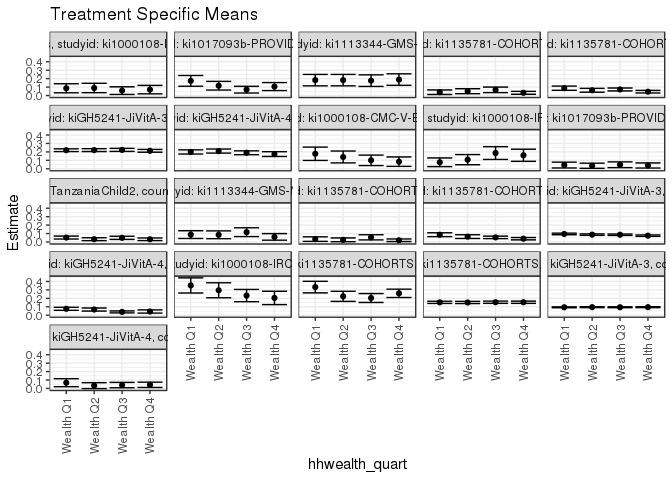

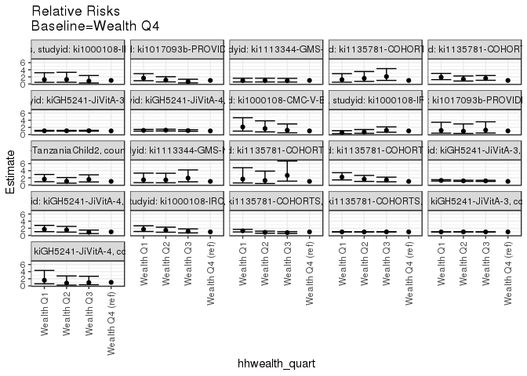

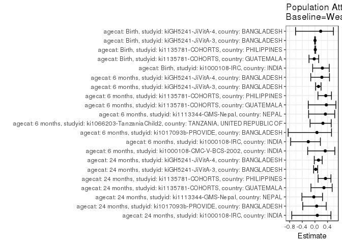

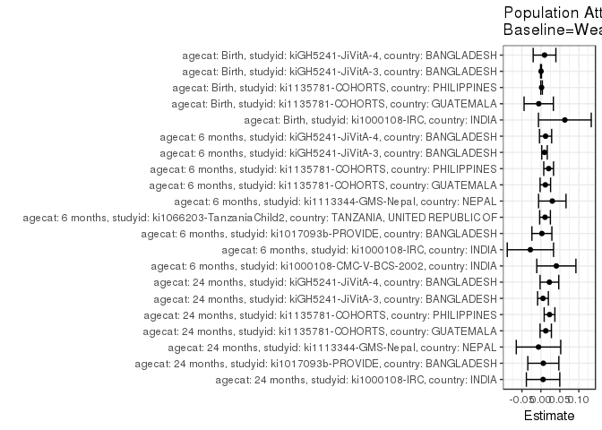

## Results Table

### Parameter: TSM

| agecat | studyid | country | intervention_level | baseline_level | estimate | ci_lower | ci_upper |
| --- | --- | --- | --- | --- | --- | --- | --- |
| Birth | ki1000108-IRC | INDIA | Wealth Q4 | NA | 0.2049740 | 0.1259925 | 0.2839556 |
| Birth | ki1000108-IRC | INDIA | Wealth Q1 | NA | 0.3530394 | 0.2633270 | 0.4427517 |
| Birth | ki1000108-IRC | INDIA | Wealth Q2 | NA | 0.2958391 | 0.2070273 | 0.3846508 |
| Birth | ki1000108-IRC | INDIA | Wealth Q3 | NA | 0.2330131 | 0.1605140 | 0.3055122 |
| Birth | ki1135781-COHORTS | GUATEMALA | Wealth Q4 | NA | 0.2594279 | 0.2100704 | 0.3087854 |
| Birth | ki1135781-COHORTS | GUATEMALA | Wealth Q1 | NA | 0.3334582 | 0.2650449 | 0.4018716 |
| Birth | ki1135781-COHORTS | GUATEMALA | Wealth Q2 | NA | 0.2237662 | 0.1639357 | 0.2835967 |
| Birth | ki1135781-COHORTS | GUATEMALA | Wealth Q3 | NA | 0.2041190 | 0.1512784 | 0.2569596 |
| Birth | ki1135781-COHORTS | PHILIPPINES | Wealth Q4 | NA | 0.1537889 | 0.1405285 | 0.1670493 |
| Birth | ki1135781-COHORTS | PHILIPPINES | Wealth Q1 | NA | 0.1527590 | 0.1394742 | 0.1660439 |
| Birth | ki1135781-COHORTS | PHILIPPINES | Wealth Q2 | NA | 0.1512283 | 0.1381137 | 0.1643429 |
| Birth | ki1135781-COHORTS | PHILIPPINES | Wealth Q3 | NA | 0.1540686 | 0.1408252 | 0.1673120 |
| Birth | kiGH5241-JiVitA-3 | BANGLADESH | Wealth Q4 | NA | 0.0955561 | 0.0903166 | 0.1007956 |
| Birth | kiGH5241-JiVitA-3 | BANGLADESH | Wealth Q1 | NA | 0.0942070 | 0.0887842 | 0.0996298 |
| Birth | kiGH5241-JiVitA-3 | BANGLADESH | Wealth Q2 | NA | 0.0954474 | 0.0901943 | 0.1007005 |
| Birth | kiGH5241-JiVitA-3 | BANGLADESH | Wealth Q3 | NA | 0.0945626 | 0.0893342 | 0.0997911 |
| Birth | kiGH5241-JiVitA-4 | BANGLADESH | Wealth Q4 | NA | 0.0430469 | 0.0117009 | 0.0743929 |
| Birth | kiGH5241-JiVitA-4 | BANGLADESH | Wealth Q1 | NA | 0.0681881 | 0.0208736 | 0.1155026 |
| Birth | kiGH5241-JiVitA-4 | BANGLADESH | Wealth Q2 | NA | 0.0335412 | -0.0016453 | 0.0687278 |
| Birth | kiGH5241-JiVitA-4 | BANGLADESH | Wealth Q3 | NA | 0.0400316 | 0.0082250 | 0.0718381 |
| 6 months | ki1000108-CMC-V-BCS-2002 | INDIA | Wealth Q4 | NA | 0.0842105 | 0.0282917 | 0.1401294 |
| 6 months | ki1000108-CMC-V-BCS-2002 | INDIA | Wealth Q1 | NA | 0.1777778 | 0.0986824 | 0.2568731 |
| 6 months | ki1000108-CMC-V-BCS-2002 | INDIA | Wealth Q2 | NA | 0.1397849 | 0.0692131 | 0.2103567 |
| 6 months | ki1000108-CMC-V-BCS-2002 | INDIA | Wealth Q3 | NA | 0.1000000 | 0.0379361 | 0.1620639 |
| 6 months | ki1000108-IRC | INDIA | Wealth Q4 | NA | 0.1600000 | 0.0880583 | 0.2319417 |
| 6 months | ki1000108-IRC | INDIA | Wealth Q1 | NA | 0.0769231 | 0.0256474 | 0.1281988 |
| 6 months | ki1000108-IRC | INDIA | Wealth Q2 | NA | 0.1078431 | 0.0475736 | 0.1681127 |
| 6 months | ki1000108-IRC | INDIA | Wealth Q3 | NA | 0.1862745 | 0.1106267 | 0.2619224 |
| 6 months | ki1017093b-PROVIDE | BANGLADESH | Wealth Q4 | NA | 0.0387097 | 0.0083152 | 0.0691041 |
| 6 months | ki1017093b-PROVIDE | BANGLADESH | Wealth Q1 | NA | 0.0437956 | 0.0094988 | 0.0780924 |

[output cut: 54 more lines]

### Parameter: E(Y)

| agecat | studyid | country | intervention_level | baseline_level | estimate | ci_lower | ci_upper |
| --- | --- | --- | --- | --- | --- | --- | --- |
| Birth | ki1000108-IRC | INDIA | NA | NA | 0.2682216 | 0.2212677 | 0.3151755 |
| Birth | ki1135781-COHORTS | GUATEMALA | NA | NA | 0.2537723 | 0.2221611 | 0.2853834 |
| Birth | ki1135781-COHORTS | PHILIPPINES | NA | NA | 0.1556246 | 0.1424244 | 0.1688248 |
| Birth | kiGH5241-JiVitA-3 | BANGLADESH | NA | NA | 0.0959786 | 0.0907764 | 0.1011808 |
| Birth | kiGH5241-JiVitA-4 | BANGLADESH | NA | NA | 0.0527086 | 0.0336587 | 0.0717585 |
| 6 months | ki1000108-CMC-V-BCS-2002 | INDIA | NA | NA | 0.1250000 | 0.0911644 | 0.1588356 |
| 6 months | ki1000108-IRC | INDIA | NA | NA | 0.1323529 | 0.0994307 | 0.1652752 |
| 6 months | ki1017093b-PROVIDE | BANGLADESH | NA | NA | 0.0413793 | 0.0251566 | 0.0576020 |
| 6 months | ki1066203-TanzaniaChild2 | TANZANIA, UNITED REPUBLIC OF | NA | NA | 0.0430906 | 0.0342310 | 0.0519502 |
| 6 months | ki1113344-GMS-Nepal | NEPAL | NA | NA | 0.0905861 | 0.0668565 | 0.1143158 |
| 6 months | ki1135781-COHORTS | GUATEMALA | NA | NA | 0.0323974 | 0.0209875 | 0.0438073 |
| 6 months | ki1135781-COHORTS | PHILIPPINES | NA | NA | 0.0594974 | 0.0505830 | 0.0684118 |
| 6 months | kiGH5241-JiVitA-3 | BANGLADESH | NA | NA | 0.0846689 | 0.0798658 | 0.0894720 |
| 6 months | kiGH5241-JiVitA-4 | BANGLADESH | NA | NA | 0.0563261 | 0.0473846 | 0.0652676 |
| 24 months | ki1000108-IRC | INDIA | NA | NA | 0.0757946 | 0.0501131 | 0.1014762 |
| 24 months | ki1017093b-PROVIDE | BANGLADESH | NA | NA | 0.1126516 | 0.0868319 | 0.1384714 |
| 24 months | ki1113344-GMS-Nepal | NEPAL | NA | NA | 0.1827309 | 0.1487560 | 0.2167058 |
| 24 months | ki1135781-COHORTS | GUATEMALA | NA | NA | 0.0449331 | 0.0323731 | 0.0574931 |
| 24 months | ki1135781-COHORTS | PHILIPPINES | NA | NA | 0.0681911 | 0.0582056 | 0.0781766 |
| 24 months | kiGH5241-JiVitA-3 | BANGLADESH | NA | NA | 0.2183090 | 0.2083912 | 0.2282269 |
| 24 months | kiGH5241-JiVitA-4 | BANGLADESH | NA | NA | 0.1963841 | 0.1829372 | 0.2098310 |

### Parameter: RR

| agecat | studyid | country | intervention_level | baseline_level | estimate | ci_lower | ci_upper |
| --- | --- | --- | --- | --- | --- | --- | --- |
| Birth | ki1000108-IRC | INDIA | Wealth Q4 | Wealth Q4 | 1.0000000 | 1.0000000 | 1.000000 |
| Birth | ki1000108-IRC | INDIA | Wealth Q1 | Wealth Q4 | 1.7223614 | 1.0998916 | 2.697110 |
| Birth | ki1000108-IRC | INDIA | Wealth Q2 | Wealth Q4 | 1.4433003 | 0.8989258 | 2.317339 |
| Birth | ki1000108-IRC | INDIA | Wealth Q3 | Wealth Q4 | 1.1367934 | 0.7072836 | 1.827130 |
| Birth | ki1135781-COHORTS | GUATEMALA | Wealth Q4 | Wealth Q4 | 1.0000000 | 1.0000000 | 1.000000 |
| Birth | ki1135781-COHORTS | GUATEMALA | Wealth Q1 | Wealth Q4 | 1.2853598 | 0.9762307 | 1.692377 |
| Birth | ki1135781-COHORTS | GUATEMALA | Wealth Q2 | Wealth Q4 | 0.8625372 | 0.6254735 | 1.189451 |
| Birth | ki1135781-COHORTS | GUATEMALA | Wealth Q3 | Wealth Q4 | 0.7868042 | 0.5740741 | 1.078364 |
| Birth | ki1135781-COHORTS | PHILIPPINES | Wealth Q4 | Wealth Q4 | 1.0000000 | 1.0000000 | 1.000000 |
| Birth | ki1135781-COHORTS | PHILIPPINES | Wealth Q1 | Wealth Q4 | 0.9933034 | 0.9699925 | 1.017175 |
| Birth | ki1135781-COHORTS | PHILIPPINES | Wealth Q2 | Wealth Q4 | 0.9833499 | 0.9612596 | 1.005948 |
| Birth | ki1135781-COHORTS | PHILIPPINES | Wealth Q3 | Wealth Q4 | 1.0018187 | 0.9784534 | 1.025742 |
| Birth | kiGH5241-JiVitA-3 | BANGLADESH | Wealth Q4 | Wealth Q4 | 1.0000000 | 1.0000000 | 1.000000 |
| Birth | kiGH5241-JiVitA-3 | BANGLADESH | Wealth Q1 | Wealth Q4 | 0.9858815 | 0.9649336 | 1.007284 |
| Birth | kiGH5241-JiVitA-3 | BANGLADESH | Wealth Q2 | Wealth Q4 | 0.9988621 | 0.9793229 | 1.018791 |
| Birth | kiGH5241-JiVitA-3 | BANGLADESH | Wealth Q3 | Wealth Q4 | 0.9896029 | 0.9696212 | 1.009996 |
| Birth | kiGH5241-JiVitA-4 | BANGLADESH | Wealth Q4 | Wealth Q4 | 1.0000000 | 1.0000000 | 1.000000 |
| Birth | kiGH5241-JiVitA-4 | BANGLADESH | Wealth Q1 | Wealth Q4 | 1.5840429 | 0.5787270 | 4.335709 |
| Birth | kiGH5241-JiVitA-4 | BANGLADESH | Wealth Q2 | Wealth Q4 | 0.7791786 | 0.2175601 | 2.790582 |
| Birth | kiGH5241-JiVitA-4 | BANGLADESH | Wealth Q3 | Wealth Q4 | 0.9299528 | 0.3206364 | 2.697174 |
| 6 months | ki1000108-CMC-V-BCS-2002 | INDIA | Wealth Q4 | Wealth Q4 | 1.0000000 | 1.0000000 | 1.000000 |
| 6 months | ki1000108-CMC-V-BCS-2002 | INDIA | Wealth Q1 | Wealth Q4 | 2.1111111 | 0.9492417 | 4.695106 |
| 6 months | ki1000108-CMC-V-BCS-2002 | INDIA | Wealth Q2 | Wealth Q4 | 1.6599462 | 0.7208115 | 3.822666 |
| 6 months | ki1000108-CMC-V-BCS-2002 | INDIA | Wealth Q3 | Wealth Q4 | 1.1875000 | 0.4785137 | 2.946950 |
| 6 months | ki1000108-IRC | INDIA | Wealth Q4 | Wealth Q4 | 1.0000000 | 1.0000000 | 1.000000 |
| 6 months | ki1000108-IRC | INDIA | Wealth Q1 | Wealth Q4 | 0.4807692 | 0.2151491 | 1.074321 |
| 6 months | ki1000108-IRC | INDIA | Wealth Q2 | Wealth Q4 | 0.6740196 | 0.3289721 | 1.380976 |
| 6 months | ki1000108-IRC | INDIA | Wealth Q3 | Wealth Q4 | 1.1642157 | 0.6351858 | 2.133861 |
| 6 months | ki1017093b-PROVIDE | BANGLADESH | Wealth Q4 | Wealth Q4 | 1.0000000 | 1.0000000 | 1.000000 |
| 6 months | ki1017093b-PROVIDE | BANGLADESH | Wealth Q1 | Wealth Q4 | 1.1313869 | 0.3732482 | 3.429451 |

[output cut: 54 more lines]

### Parameter: PAR

| agecat | studyid | country | intervention_level | baseline_level | estimate | ci_lower | ci_upper |
| --- | --- | --- | --- | --- | --- | --- | --- |
| Birth | ki1000108-IRC | INDIA | Wealth Q4 | NA | 0.0632476 | -0.0062954 | 0.1327905 |
| Birth | ki1135781-COHORTS | GUATEMALA | Wealth Q4 | NA | -0.0056556 | -0.0442931 | 0.0329819 |
| Birth | ki1135781-COHORTS | PHILIPPINES | Wealth Q4 | NA | 0.0018357 | -0.0002692 | 0.0039406 |
| Birth | kiGH5241-JiVitA-3 | BANGLADESH | Wealth Q4 | NA | 0.0004225 | -0.0008587 | 0.0017036 |
| Birth | kiGH5241-JiVitA-4 | BANGLADESH | Wealth Q4 | NA | 0.0096617 | -0.0202510 | 0.0395744 |
| 6 months | ki1000108-CMC-V-BCS-2002 | INDIA | Wealth Q4 | NA | 0.0407895 | -0.0107598 | 0.0923387 |
| 6 months | ki1000108-IRC | INDIA | Wealth Q4 | NA | -0.0276471 | -0.0886587 | 0.0333646 |
| 6 months | ki1017093b-PROVIDE | BANGLADESH | Wealth Q4 | NA | 0.0026696 | -0.0236597 | 0.0289989 |
| 6 months | ki1066203-TanzaniaChild2 | TANZANIA, UNITED REPUBLIC OF | Wealth Q4 | NA | 0.0109468 | -0.0032148 | 0.0251084 |
| 6 months | ki1113344-GMS-Nepal | NEPAL | Wealth Q4 | NA | 0.0301094 | -0.0060112 | 0.0662300 |
| 6 months | ki1135781-COHORTS | GUATEMALA | Wealth Q4 | NA | 0.0117484 | -0.0020944 | 0.0255913 |
| 6 months | ki1135781-COHORTS | PHILIPPINES | Wealth Q4 | NA | 0.0204857 | 0.0076016 | 0.0333699 |
| 6 months | kiGH5241-JiVitA-3 | BANGLADESH | Wealth Q4 | NA | 0.0095786 | 0.0023521 | 0.0168050 |
| 6 months | kiGH5241-JiVitA-4 | BANGLADESH | Wealth Q4 | NA | 0.0123803 | -0.0036714 | 0.0284320 |
| 24 months | ki1000108-IRC | INDIA | Wealth Q4 | NA | 0.0057946 | -0.0382574 | 0.0498467 |
| 24 months | ki1017093b-PROVIDE | BANGLADESH | Wealth Q4 | NA | 0.0064517 | -0.0344369 | 0.0473402 |
| 24 months | ki1113344-GMS-Nepal | NEPAL | Wealth Q4 | NA | -0.0062455 | -0.0648139 | 0.0523230 |
| 24 months | ki1135781-COHORTS | GUATEMALA | Wealth Q4 | NA | 0.0128343 | -0.0021425 | 0.0278111 |
| 24 months | ki1135781-COHORTS | PHILIPPINES | Wealth Q4 | NA | 0.0228091 | 0.0087162 | 0.0369021 |
| 24 months | kiGH5241-JiVitA-3 | BANGLADESH | Wealth Q4 | NA | 0.0055695 | -0.0085930 | 0.0197320 |
| 24 months | kiGH5241-JiVitA-4 | BANGLADESH | Wealth Q4 | NA | 0.0224967 | -0.0021110 | 0.0471044 |

### Parameter: PAF

| agecat | studyid | country | intervention_level | baseline_level | estimate | ci_lower | ci_upper |
| --- | --- | --- | --- | --- | --- | --- | --- |
| Birth | ki1000108-IRC | INDIA | Wealth Q4 | NA | 0.2358034 | -0.0703636 | 0.4543943 |
| Birth | ki1135781-COHORTS | GUATEMALA | Wealth Q4 | NA | -0.0222862 | -0.1865642 | 0.1192477 |
| Birth | ki1135781-COHORTS | PHILIPPINES | Wealth Q4 | NA | 0.0117955 | -0.0018086 | 0.0252149 |
| Birth | kiGH5241-JiVitA-3 | BANGLADESH | Wealth Q4 | NA | 0.0044015 | -0.0090160 | 0.0176407 |
| Birth | kiGH5241-JiVitA-4 | BANGLADESH | Wealth Q4 | NA | 0.1833046 | -0.6118603 | 0.5861978 |
| 6 months | ki1000108-CMC-V-BCS-2002 | INDIA | Wealth Q4 | NA | 0.3263158 | -0.2283944 | 0.6305336 |
| 6 months | ki1000108-IRC | INDIA | Wealth Q4 | NA | -0.2088889 | -0.7673694 | 0.1731144 |
| 6 months | ki1017093b-PROVIDE | BANGLADESH | Wealth Q4 | NA | 0.0645161 | -0.8459385 | 0.5259159 |
| 6 months | ki1066203-TanzaniaChild2 | TANZANIA, UNITED REPUBLIC OF | Wealth Q4 | NA | 0.2540409 | -0.1528003 | 0.5173015 |
| 6 months | ki1113344-GMS-Nepal | NEPAL | Wealth Q4 | NA | 0.3323844 | -0.1990144 | 0.6282692 |
| 6 months | ki1135781-COHORTS | GUATEMALA | Wealth Q4 | NA | 0.3626352 | -0.2100558 | 0.6642850 |
| 6 months | ki1135781-COHORTS | PHILIPPINES | Wealth Q4 | NA | 0.3443129 | 0.0956594 | 0.5245977 |
| 6 months | kiGH5241-JiVitA-3 | BANGLADESH | Wealth Q4 | NA | 0.1131299 | 0.0238033 | 0.1942826 |
| 6 months | kiGH5241-JiVitA-4 | BANGLADESH | Wealth Q4 | NA | 0.2197971 | -0.1309182 | 0.4617502 |
| 24 months | ki1000108-IRC | INDIA | Wealth Q4 | NA | 0.0764516 | -0.7319580 | 0.5075275 |
| 24 months | ki1017093b-PROVIDE | BANGLADESH | Wealth Q4 | NA | 0.0572708 | -0.3848014 | 0.3582197 |
| 24 months | ki1113344-GMS-Nepal | NEPAL | Wealth Q4 | NA | -0.0341784 | -0.4098728 | 0.2414032 |
| 24 months | ki1135781-COHORTS | GUATEMALA | Wealth Q4 | NA | 0.2856317 | -0.1247612 | 0.5462841 |
| 24 months | ki1135781-COHORTS | PHILIPPINES | Wealth Q4 | NA | 0.3344883 | 0.1000517 | 0.5078541 |
| 24 months | kiGH5241-JiVitA-3 | BANGLADESH | Wealth Q4 | NA | 0.0255118 | -0.0414729 | 0.0881882 |
| 24 months | kiGH5241-JiVitA-4 | BANGLADESH | Wealth Q4 | NA | 0.1145545 | -0.0204467 | 0.2316956 |